# Group Predictions

0.5200

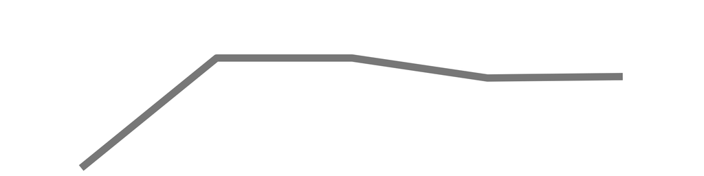

Bradley Hobson

8

10

11

12

8

0.5714

5

0.6447

0.6447

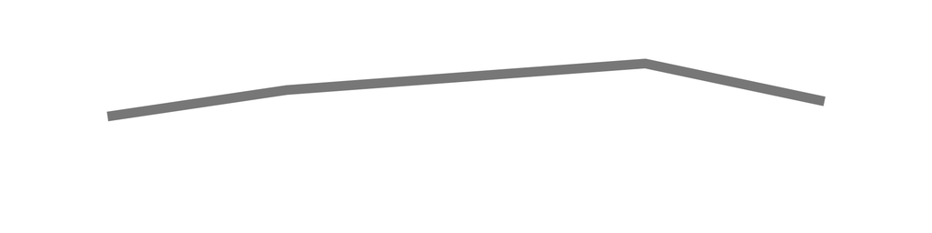

William Schouviller

10

9

11

10

8

0.5714

5

0.6316

0.6316

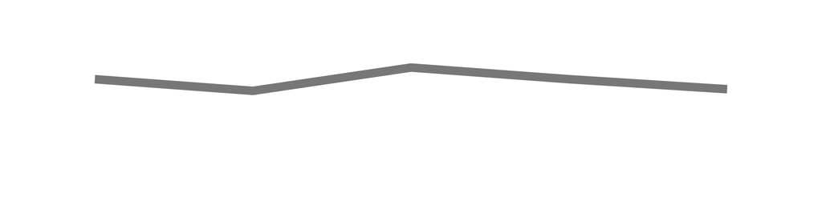

Paul Presti

9

10

12

9

8

0.5714

5

0.6316

0.6316

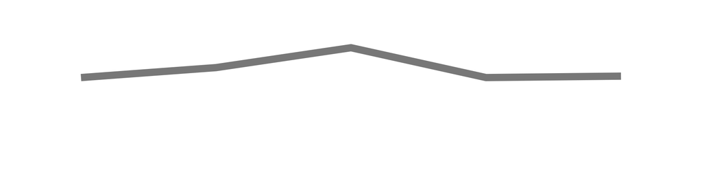

Rahmatullah Sharifi

11

9

8

11

8

0.5714

5

0.6184

0.6184

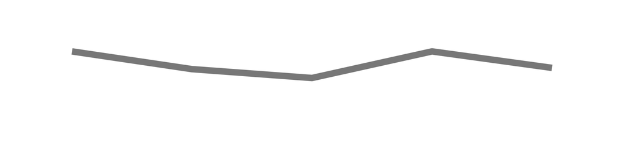

Kevin Green

9

12

9

9

8

0.5714

5

0.6184

0.6184

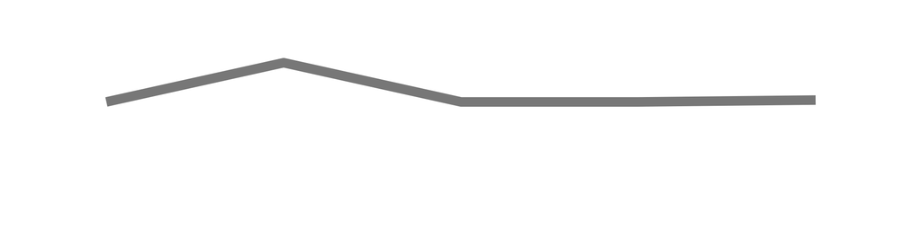

Eric Hahn

9

13

7

9

8

0.5714

5

0.6053

0.6053

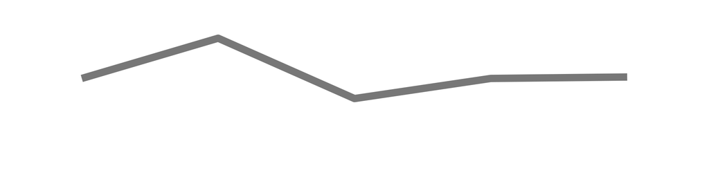

Brian Hollmann

8

13

8

9

8

0.5714

5

0.6053

0.6053

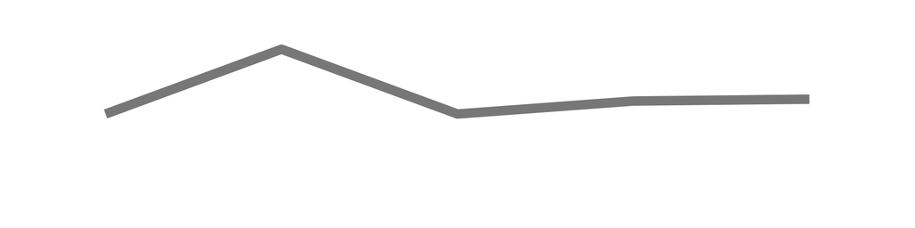

James Small

8

8

13

9

8

0.5714

5

0.6053

0.6053

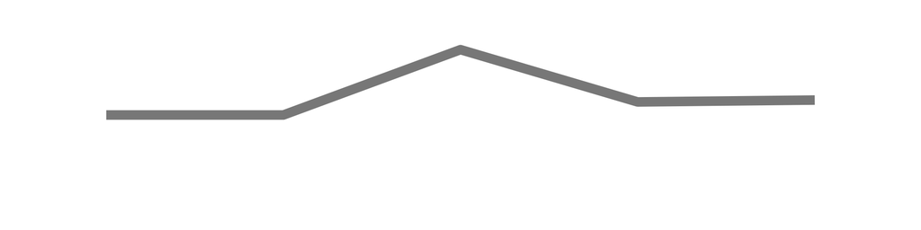

Daniel Baller

6

12

11

9

8

0.5714

5

0.6053

0.6053

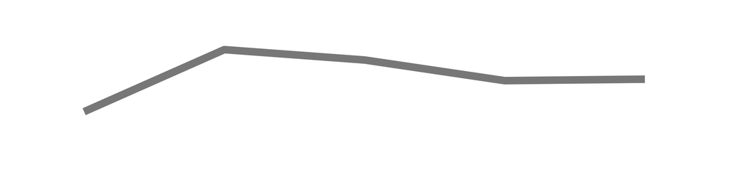

WAYNE SCHOFIELD

12

9

7

NA

8

0.5714

4

0.6000

0.4800

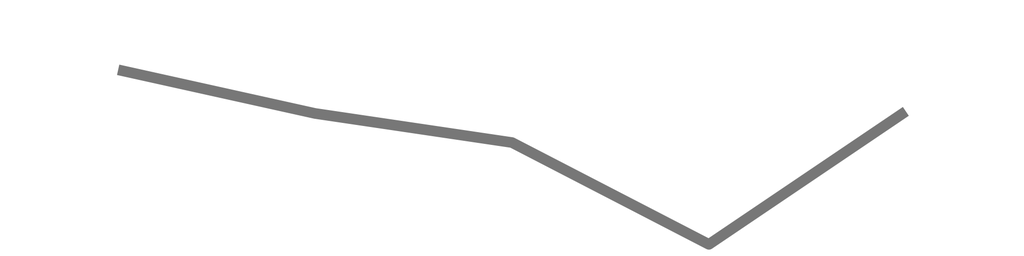

Shelly Bailey

9

10

NA

10

8

0.5714

4

0.5968

0.4774

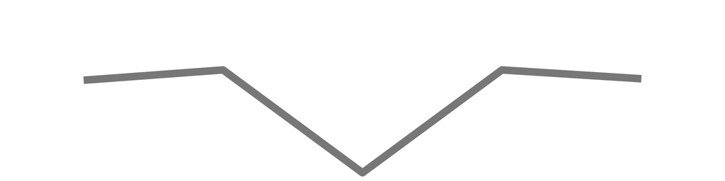

Steven Curtis

NA

NA

11

7

8

0.5714

3

0.5909

0.3545

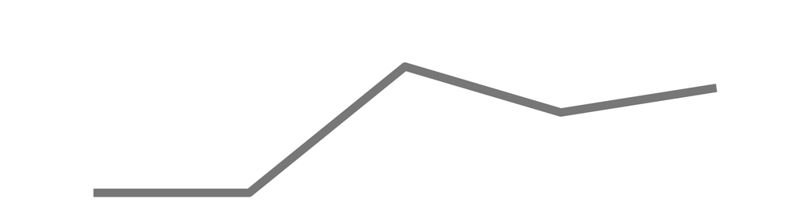

Gregory Flint

6

11

NA

11

8

0.5714

4

0.5806

0.4645

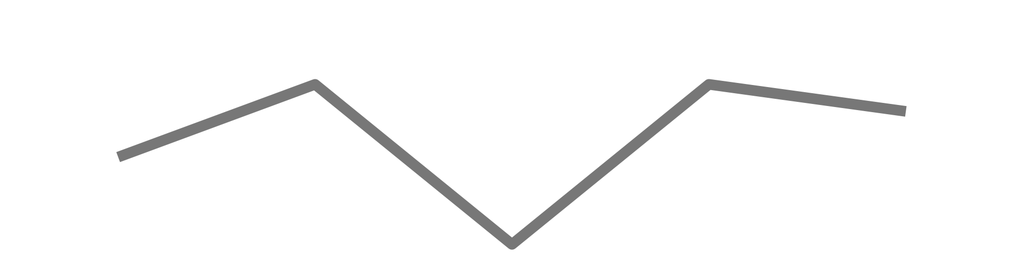

Shawn Carden

9

12

6

9

8

0.5714

5

0.5789

0.5789

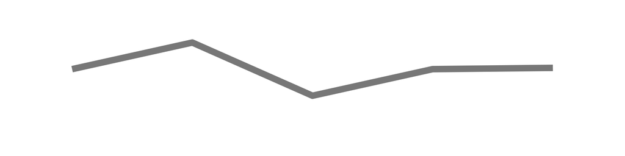

Thomas Brenstuhl

10

NA

8

8

8

0.5714

4

0.5667

0.4534

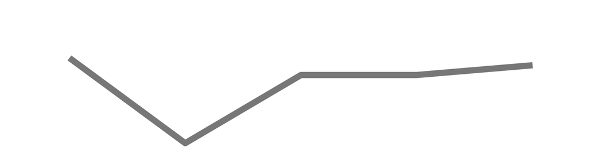

Karen Coleman

7

10

NA

10

8

0.5714

4

0.5645

0.4516

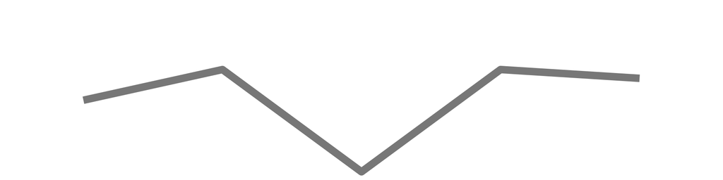

Daniel Major

8

13

6

7

8

0.5714

5

0.5526

0.5526

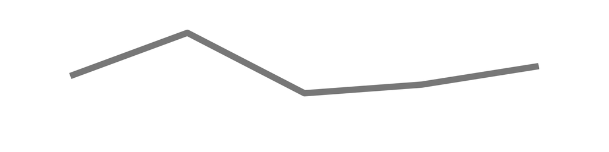

THOMAS MCCOY

8

10

9

7

8

0.5714

5

0.5526

0.5526

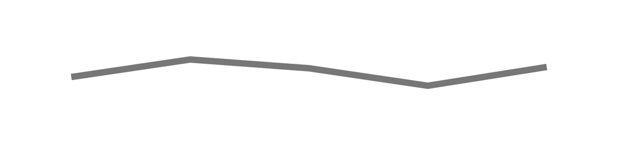

DAVID PLATE

8

NA

8

9

8

0.5714

4

0.5500

0.4400

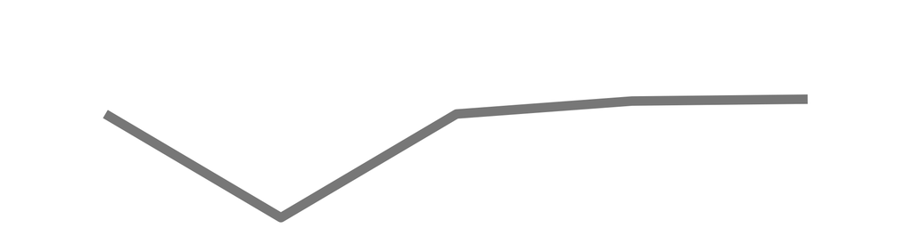

Michael Moss

10

NA

11

13

7

0.5000

4

0.6833

0.5466

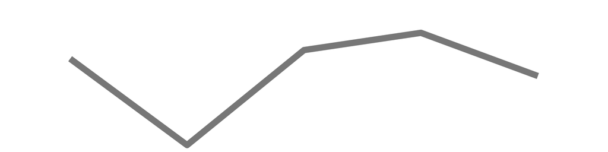

Kevin O'NEILL

8

11

11

13

7

0.5000

5

0.6579

0.6579

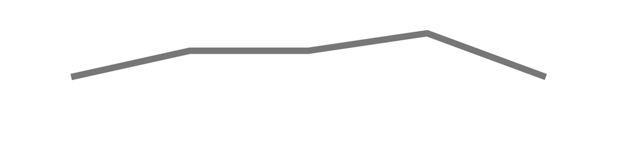

Ryan Wiggins

8

11

11

12

7

0.5000

5

0.6447

0.6447

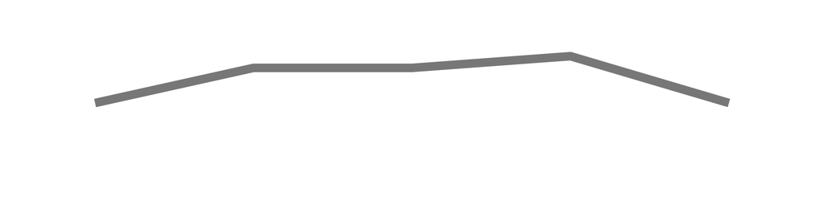

George Sweet

9

11

10

12

7

0.5000

5

0.6447

0.6447

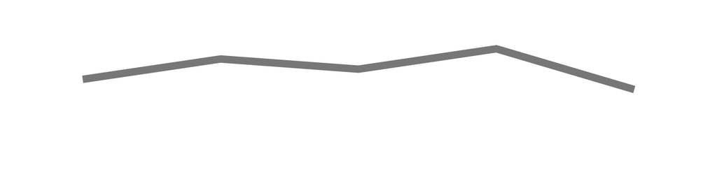

Kevin Kehoe

9

10

11

12

7

0.5000

5

0.6447

0.6447

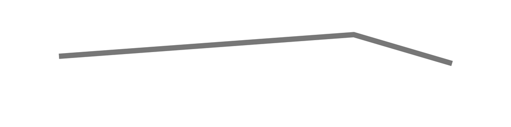

PABLO BURGOSRAMOS

9

11

10

12

7

0.5000

5

0.6447

0.6447

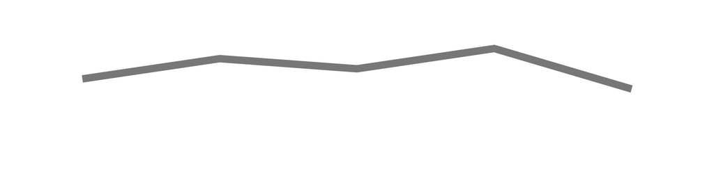

Manuel Vargas

10

9

11

12

7

0.5000

5

0.6447

0.6447

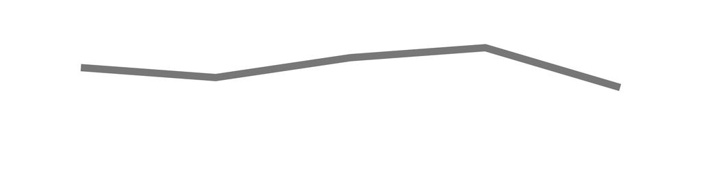

Vincent Scannelli

11

11

8

11

7

0.5000

5

0.6316

0.6316

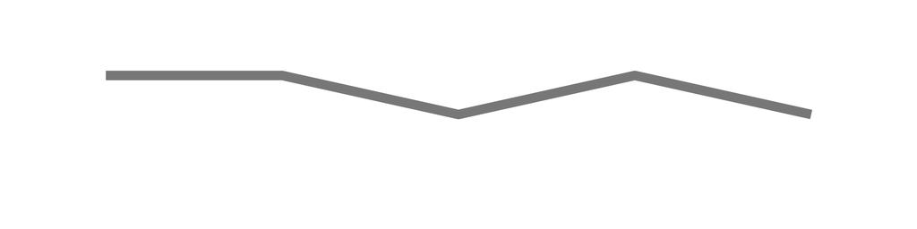

Paul Shim

10

9

10

11

7

0.5000

5

0.6184

0.6184

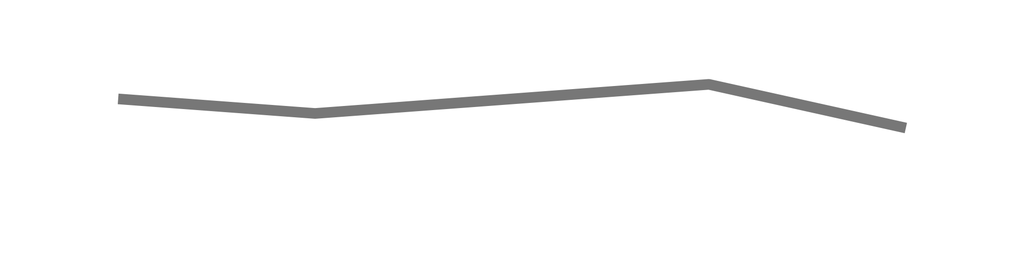

Terry Hardison

10

10

9

11

7

0.5000

5

0.6184

0.6184

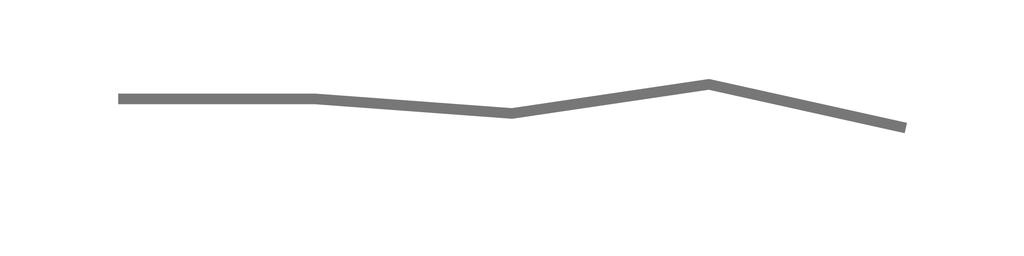

Yiming Hu

9

10

8

12

7

0.5000

5

0.6053

0.6053

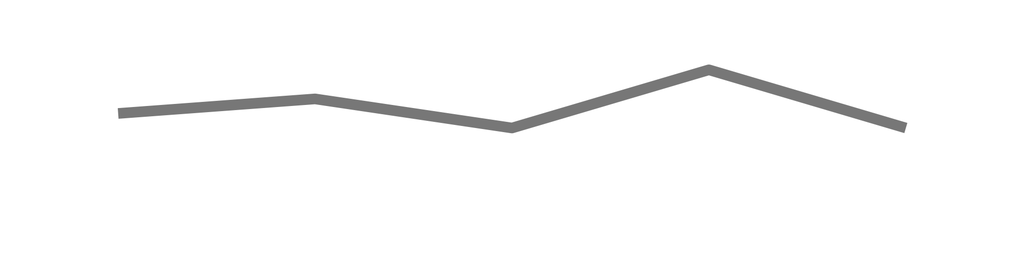

Brian Patterson

10

10

8

11

7

0.5000

5

0.6053

0.6053

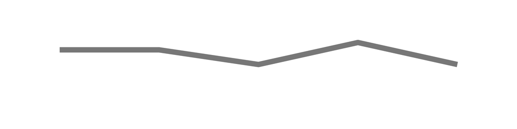

Cody Koerwitz

7

9

11

12

7

0.5000

5

0.6053

0.6053

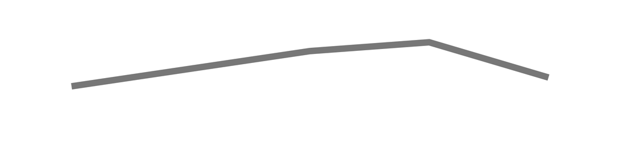

Walter Archambo

7

10

10

11

7

0.5000

5

0.5921

0.5921

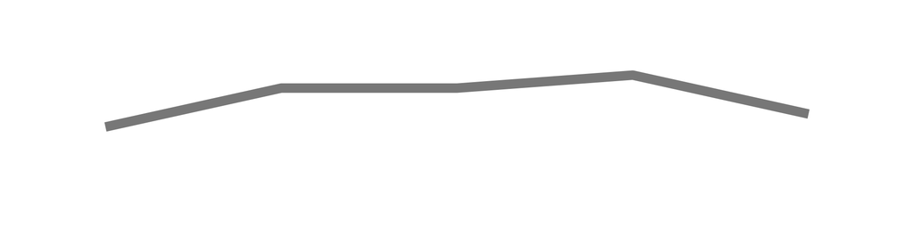

Khalil Ibrahim

7

12

9

NA

7

0.5000

4

0.5833

0.4666

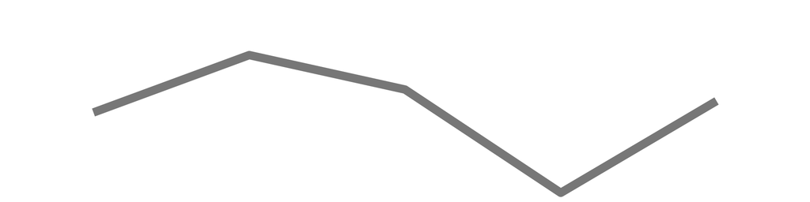

Patrick Tynan

8

8

10

11

7

0.5000

5

0.5789

0.5789

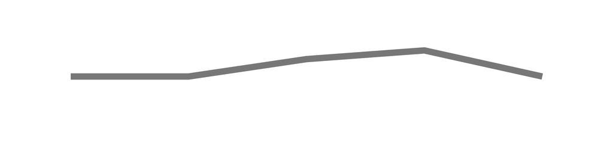

Jonathon Leslein

9

9

9

9

7

0.5000

5

0.5658

0.5658

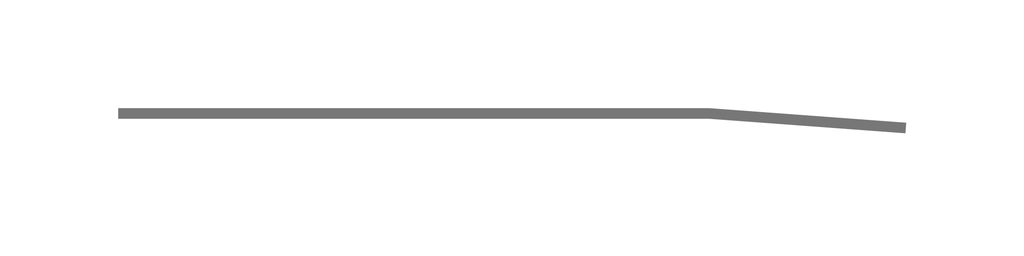

Stephen Bush

7

10

10

9

7

0.5000

5

0.5658

0.5658

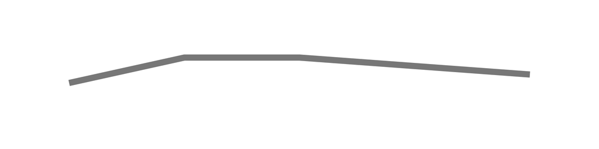

Shaun Dahl

8

8

10

10

7

0.5000

5

0.5658

0.5658

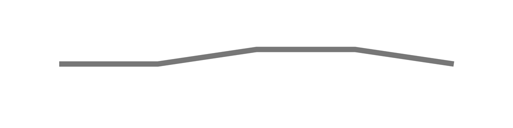